# AI Project 1

Farbod Azimmohseni 810100187

In the first place we need to transform our *curve fitting* problem into a *genetic algorithm* problem.The goal is to choose coefficients in a way that minimizes the distance between input points and the found polynomial. *Numpy* library is included and vectorization is used instead of *for* loops whenever possible to increase the speed of algorithm.

```python
import numpy as np
import math
import random
import matplotlib.pyplot as plt
from matplotlib.ticker import MultipleLocator
```

The inputs for this problem include the order of the polynomial, the range of coefficient intervals, and multiple points on the polynomial. Additionally, several parameters of the algorithm need to be set, such as the number of populations, the fitness function, the crossover chance, and the mutation chance.

In this notebook, we will discuss the impact of population size and mutation chance on the speed of solving the problem.

```python
order_of_polynomial = 5
number_of_chromosomes = 1000
number_of_points = 10


def calc_poly(coeficiont,x):
    result = 0
    for i,co in enumerate(coeficiont):
        result += (co* (x**i))
    return result
# initial_points = np.random.rand(number_of_points,2)
# initial_points = [[random.randint(-5,5),random.randint(-5,5)] for i in range(number_of_points)]
# initial_points = [[(random.random()*50)-25,(random.random()*50)-25] for i in range(number_of_points)]
poly_coefs = [random.randint(-5,5) for i in range(order_of_polynomial+1)]
x_s = [(random.random())-0.5 for i in range(number_of_points)]
y_s = [calc_poly(poly_coefs,x_s[i]) for i in range(number_of_points)]
initial_points = [[x_s[i],y_s[i]] for i in range(number_of_points)]
```

# Zero Generation

First population is generated randomely where each coefficient is a gene and a chromosomes form all coefficients of the polynomial. Function *generateinitialgeneration* returns 2D *numpy* array with shape (numberofchromosomes,numberofgenes)

```python
def generate_initial_generation(number_of_genes,n_chroms,gene_ranges):
    zero_gen = np.zeros((n_chroms,number_of_genes))
    for i in range(n_chroms):
        zero_gen[i,:] = np.array([[random.randint(gene_ranges[j][0],gene_ranges[j][1]) for j in range(number_of_genes)]])
    return zero_gen
```

# Setting Fitness Function

[figure not shown]

Fitness function is calculated as follow:

[figure not shown]

```python
def polynomial_out(generation,poly_order,x):
    x_s = np.array([x**i for i in range(poly_order+1)])
    x_s = np.reshape(x_s,(poly_order+1,1))
    res = np.matmul(generation,x_s)
    result = np.reshape(res,(1,generation.shape[0]))
    return result





def fitness_function(generation,points,n_of_chromes,poly_order):
    res = np.zeros((1,generation.shape[0]))
    for i in range(len(points)):
        res += np.power(polynomial_out(generation,poly_order,points[i][0]) -points[i][1],2)
    error =[[res[0,i],i] for i in range(n_of_chromes)]
    error.sort()
    mean = np.sum(res)/n_of_chromes
    min = error[0][0]
    minarg = error[0][1]
    error.reverse()
    return error,mean,min,np.copy(generation[minarg])
```

# Chromosomes of next generation

In this step all chromosomes are ranked based on their fitness and a probability is assigned to them.Chromosomes are picked based on their probability. The number of chromosomes is the same in all generations. Replacement is allowed.

```python
def generate_chromosomes_for_next_gen(sorted_fitnesses,n_chrom,poly_order,chromosomes):
    new_chromosomes = np.zeros((n_chrom,poly_order+1))
    for i in range(n_chrom):
        rand = random.randint(1,((n_chrom*(n_chrom+1))//2))
        new_gen_chrome = sorted_fitnesses[(math.ceil((-1+math.sqrt(1+(8*rand)))/2))-1][1]
        new_chromosomes[i,:] = np.copy(chromosomes[new_gen_chrome,:])
    return new_chromosomes
```

# Crossover

There are several methods for crossover such as One-point crossover and two point crossover.

```python
crossover_chance = 0.6

def cross_over(generation):
    n_chromes,n_genes = generation.shape
    for i in range(n_chromes//2):
        rand = random.random()
        if rand <= crossover_chance:
            mid = n_genes//2
            temp1 = np.copy(generation[2*i,:mid])
            temp2 = np.copy(generation[2*i,mid:])
            rand2 = random.randint(0,1)
            if rand2 == 0:
                generation[2*i,:mid] =np.copy(generation[(2*i)+1,:mid])
                generation[(2*i)+1,:mid] = temp1
            else :
                generation[2*i,mid:] = np.copy(generation[(2*i)+1,mid:])
                generation[(2*i)+1,mid:] = temp2
    return generation
```

# mutation

Mutation makes sure that we can explore for better answers and helps us not to get stuck in a local minimum or maximum.

```python
def mutate(generation,gen_ranges,mutate_chance):
    n_chromes,n_genes = generation.shape
    for i in range(n_chromes):
        rand = random.random()
        if rand <= mutate_chance:
            rand2 = random.randint(0,n_genes-1)
            generation[i,rand2] = random.randint(gen_ranges[rand2][0],gen_ranges[rand2][1])
    return generation
```

# Running Algorithm

```
fitness in itr0, mean:1579.527, min:0.537
fitness in itr50, mean:132.078, min:0.06
fitness in itr100, mean:130.065, min:0.052
fitness in itr150, mean:174.259, min:0.052
fitness in itr200, mean:127.519, min:0.052
fitness in itr250, mean:122.038, min:0.051
fitness in itr300, mean:117.951, min:0.051
fitness in itr350, mean:149.501, min:0.052
fitness in itr400, mean:124.902, min:0.052
fitness in itr450, mean:123.869, min:0.052
fitness in itr500, mean:151.588, min:0.052
fitness in itr550, mean:147.466, min:0.052
fitness in itr600, mean:109.791, min:0.052
fitness in itr650, mean:128.114, min:0.052
fitness in itr700, mean:119.153, min:0.05
fitness in itr750, mean:136.826, min:0.052
fitness in itr800, mean:168.08, min:0.052
fitness in itr850, mean:140.043, min:0.05
fitness in itr900, mean:145.708, min:0.051
fitness in itr950, mean:131.751, min:0.052
fitness in itr1000, mean:129.479, min:0.05
fitness in itr1050, mean:132.81, min:0.05
fitness in itr1100, mean:113.572, min:0.05
fitness in itr1150, mean:146.691, min:0.051
fitness in itr1200, mean:141.978, min:0.05
fitness in itr1250, mean:121.851, min:0.052
fitness in itr1300, mean:144.855, min:0.052
fitness in itr1350, mean:146.097, min:0.05
fitness in itr1400, mean:167.154, min:0.05
fitness in itr1450, mean:131.788, min:0.05
fitness in itr1500, mean:121.831, min:0.05
fitness in itr1550, mean:137.604, min:0.051
fitness in itr1600, mean:140.946, min:0.05
fitness in itr1650, mean:126.688, min:0.05
fitness in itr1700, mean:145.622, min:0.05
fitness in itr1750, mean:124.826, min:0.05
fitness in itr1800, mean:119.153, min:0.05
fitness in itr1850, mean:154.677, min:0.05
fitness in itr1900, mean:132.0, min:0.05
fitness in itr1950, mean:140.281, min:0.05
```

[output cut: 46 more lines]

```
fitness in itr4300, mean:137.045, min:0.052
fitness in itr4350, mean:161.476, min:0.052
fitness in itr4400, mean:129.4, min:0.052
fitness in itr4450, mean:154.275, min:0.052
fitness in itr4500, mean:125.05, min:0.052
fitness in itr4550, mean:154.377, min:0.051
fitness in itr4600, mean:125.807, min:0.05
fitness in itr4650, mean:161.543, min:0.05
fitness in itr4700, mean:138.738, min:0.043
fitness in itr4750, mean:119.239, min:0.05
fitness in itr4800, mean:147.036, min:0.05
fitness in itr4850, mean:141.708, min:0.05
fitness in itr4900, mean:129.39, min:0.05
fitness in itr4950, mean:150.079, min:0.05
[ -1.  -2.   0. -11.   0.  20.]
```

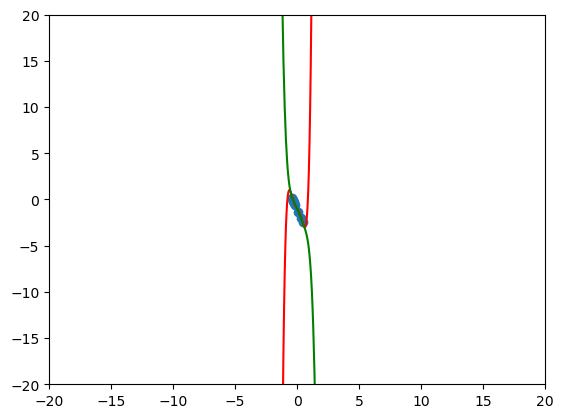

```python
number_of_steps = 5000
def GeneticAlgorithm(number_of_chromoes,mutate_chance,show_per_itr,points,poly_order,show_fitnees = True):
    mean_err_list = np.zeros((number_of_steps//show_per_itr,))
    min_err_list = np.zeros((number_of_steps//show_per_itr,))

    gene_ranges = [[-20,20] for i in range(poly_order+1)]
    generation = generate_initial_generation(poly_order+1,number_of_chromoes,gene_ranges)
    for i in range(number_of_steps):
        fitnesses,mean_er,min_er,best_coef =  fitness_function(np.copy(generation),np.copy(points),number_of_chromoes,poly_order)
        if i%show_per_itr == 0:
            if show_fitnees:
                print(f"fitness in itr{i}, mean:{round(mean_er,3)}, min:{round(min_er,3)}")
            mean_err_list[i//show_per_itr] = mean_er
            min_err_list[i//show_per_itr] = min_er

        generation = generate_chromosomes_for_next_gen(fitnesses,number_of_chromoes,poly_order,np.copy(generation))
        generation = cross_over(np.copy(generation))
        generation = mutate(np.copy(generation),gene_ranges.copy(),mutate_chance)
    return generation,mean_err_list,min_err_list,best_coef
_,_,_,best_coefficient = GeneticAlgorithm(number_of_chromosomes,0.5,50,initial_points,order_of_polynomial)
x_s = [initial_points[i][0] for i in range(len(initial_points))]
y_s = [initial_points[i][1] for i in range(len(initial_points))]
plt.scatter(x_s,y_s)
poly_points = np.arange(-40,40,0.05)
real_y_s =[calc_poly(poly_coefs,poly_points[i]) for i in range(len(poly_points))]
poly_y = [calc_poly(best_coefficient,x) for x in poly_points]
plt.plot(poly_points,poly_y,"red")
plt.plot(poly_points,real_y_s,"g")
plt.ylim(-20,20)
plt.xlim(-20,20)
plt.plot()
print(best_coefficient)
```

# Genetic algorithm with increasing population size

```python
def increase_population(generation, population_increase,gene_ranges,number_of_genes):
    new_population = np.zeros((population_increase,number_of_genes))
    for i in range(population_increase):
        new_population[i,:] = np.array([[random.randint(gene_ranges[j][0],gene_ranges[j][1]) for j in range(number_of_genes)]])
    return np.concatenate((np.copy(generation),new_population),axis = 0)
```

```
fitness in itr0, mean:38265.338, min:231.28
fitness in itr50, mean:1721.383, min:0.801
fitness in itr100, mean:1474.604, min:0.8
fitness in itr150, mean:1775.946, min:0.69
fitness in itr200, mean:1610.539, min:0.58
fitness in itr250, mean:2063.486, min:0.573
fitness in itr300, mean:2351.878, min:0.508
fitness in itr350, mean:1700.58, min:0.573
fitness in itr400, mean:1917.451, min:0.509
fitness in itr450, mean:2811.787, min:0.551
fitness in itr500, mean:2138.563, min:0.458
fitness in itr550, mean:1606.748, min:0.438
fitness in itr600, mean:2046.88, min:0.365
fitness in itr650, mean:1924.707, min:0.349
fitness in itr700, mean:1773.755, min:0.349
fitness in itr750, mean:1600.013, min:0.297
fitness in itr800, mean:1575.965, min:0.349
fitness in itr850, mean:2029.019, min:0.349
fitness in itr900, mean:2406.609, min:0.349
fitness in itr950, mean:1612.741, min:0.349
fitness in itr1000, mean:1699.603, min:0.349
fitness in itr1050, mean:1898.688, min:0.349
fitness in itr1100, mean:1546.699, min:0.349
fitness in itr1150, mean:2098.394, min:0.349
fitness in itr1200, mean:2359.287, min:0.349
fitness in itr1250, mean:2057.194, min:0.349
fitness in itr1300, mean:1878.739, min:0.349
fitness in itr1350, mean:1635.322, min:0.349
fitness in itr1400, mean:1849.475, min:0.349
fitness in itr1450, mean:1822.797, min:0.349
fitness in itr1500, mean:1695.638, min:0.349
fitness in itr1550, mean:2062.638, min:0.349
fitness in itr1600, mean:1742.217, min:0.349
fitness in itr1650, mean:1254.996, min:0.349
fitness in itr1700, mean:1700.491, min:0.349
fitness in itr1750, mean:1837.093, min:0.349
fitness in itr1800, mean:1569.458, min:0.349
fitness in itr1850, mean:2045.792, min:0.349
fitness in itr1900, mean:1739.63, min:0.349
fitness in itr1950, mean:2379.276, min:0.349
```

[output cut: 46 more lines]

```
fitness in itr4300, mean:2021.297, min:0.349
fitness in itr4350, mean:1944.101, min:0.349
fitness in itr4400, mean:1969.135, min:0.349
fitness in itr4450, mean:2949.949, min:0.349
fitness in itr4500, mean:2011.742, min:0.349
fitness in itr4550, mean:1724.279, min:0.349
fitness in itr4600, mean:1703.441, min:0.349
fitness in itr4650, mean:1891.683, min:0.349
fitness in itr4700, mean:2014.838, min:0.349
fitness in itr4750, mean:1654.061, min:0.349
fitness in itr4800, mean:2462.239, min:0.349
fitness in itr4850, mean:2021.576, min:0.349
fitness in itr4900, mean:2447.586, min:0.349
fitness in itr4950, mean:1741.22, min:0.349
[  -1.   -5.   -9.   24.   57. -100.]
```

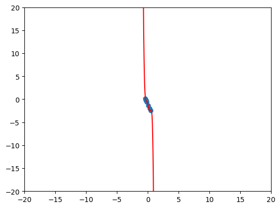

```python
number_of_steps = 5000
increase_after_steps = 100
population_increase = 5
def GeneticAlgorithmWithPopulationIncrease(number_of_chromoes,mutate_chance,show_per_itr,points,poly_order,show_fitnees = True):
    mean_err_list = np.zeros((number_of_steps//show_per_itr,))
    min_err_list = np.zeros((number_of_steps//show_per_itr,))
    n_c = number_of_chromoes
    gene_ranges = [[-100,100] for i in range(poly_order+1)]
    generation = generate_initial_generation(poly_order+1,number_of_chromoes,gene_ranges)
    for i in range(number_of_steps):
        fitnesses,mean_er,min_er,best_coef =  fitness_function(np.copy(generation),np.copy(points),number_of_chromoes,poly_order)
        if i%show_per_itr == 0:
            if show_fitnees:
                print(f"fitness in itr{i}, mean:{round(mean_er,3)}, min:{round(min_er,3)}")
            mean_err_list[i//show_per_itr] = mean_er
            min_err_list[i//show_per_itr] = min_er
        generation = generate_chromosomes_for_next_gen(fitnesses,number_of_chromoes,poly_order,np.copy(generation))
        generation = cross_over(np.copy(generation))
        generation = mutate(np.copy(generation),gene_ranges.copy(),mutate_chance)
        if i % increase_after_steps == 0:
            generation = increase_population(generation,population_increase,gene_ranges,poly_order+1)
            n_c += population_increase
    return generation,mean_err_list,min_err_list,best_coef

_,_,generation,best_coefficient = GeneticAlgorithmWithPopulationIncrease(1000,0.3,50,initial_points,order_of_polynomial,True)
x_s = [initial_points[i][0] for i in range(len(initial_points))]
y_s = [initial_points[i][1] for i in range(len(initial_points))]
plt.scatter(x_s,y_s)
poly_points = np.arange(-20,20,0.05)

poly_y = [calc_poly(best_coefficient,x) for x in poly_points]
plt.plot(poly_points,poly_y,"red")
plt.ylim(-20,20)
plt.xlim(-20,20)
plt.plot()
print(best_coefficient)
```

# Plots and comparison

Affect of population is shown in the this plot

```
[]
```

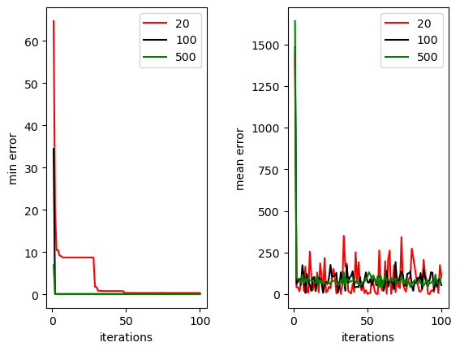

```python
n_of_chromes = [20,100,500]
result_per_itr = 50


colors = ['red','black','green']
itrs = np.arange(1,(number_of_steps//result_per_itr)+1)
fig, (ax1, ax2) = plt.subplots(1, 2)
x_major_locator = MultipleLocator(50)  # Set the tick spacing to 1.0
ax1.legend("Mean Error")
ax2.legend("Min Error")
ax1.xaxis.set_major_locator(x_major_locator)
ax2.xaxis.set_major_locator(x_major_locator)
for i in range(len(n_of_chromes)):
    generation,mean_error_list,min_error_list,_ = GeneticAlgorithm(n_of_chromes[i],0.3,result_per_itr,initial_points,order_of_polynomial,show_fitnees=False)
    ax1.plot(itrs,min_error_list,colors[i])
    ax2.plot(itrs,mean_error_list,colors[i])
ax1.legend(['20','100','500'], loc = 'upper right')
ax2.legend(['20','100','500'], loc = 'upper right')
ax1.set_xlabel("iterations")
ax1.set_ylabel("min error")
ax2.set_xlabel("iterations")
ax2.set_ylabel("mean error")
plt.subplots_adjust(wspace= 0.5)
plt.plot()
plt.plot()
```

# Comparison for different mutation chances.

```
[]
```

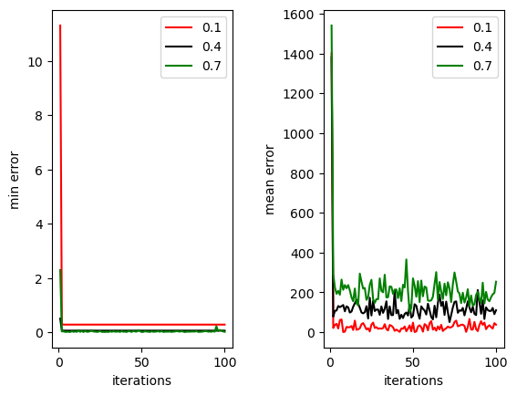

```python
n_of_chromes = 200
mutation_chances = [0.1,0.4,0.7]
result_per_itr = 50


colors = ['red','black','green']
itrs = np.arange(1,(number_of_steps//result_per_itr)+1)
fig, (ax1, ax2) = plt.subplots(1, 2)
x_major_locator = MultipleLocator(50.0)  # Set the tick spacing to 1.0
ax1.legend("Mean Error")
ax2.legend("Min Error")
ax1.xaxis.set_major_locator(x_major_locator)
ax2.xaxis.set_major_locator(x_major_locator)
for i in range(len(mutation_chances)):
    generation,mean_error_list,min_error_list,_ = GeneticAlgorithm(n_of_chromes,mutation_chances[i],result_per_itr,initial_points,order_of_polynomial,show_fitnees=False)
    ax1.plot(itrs,min_error_list,colors[i])
    ax2.plot(itrs,mean_error_list,colors[i])
ax1.legend(['0.1','0.4','0.7'], loc = 'upper right')
ax2.legend(['0.1','0.4','0.7'], loc = 'upper right')
ax1.set_xlabel("iterations")
ax1.set_ylabel("min error")
ax2.set_xlabel("iterations")
ax2.set_ylabel("mean error")
plt.subplots_adjust(wspace= 0.5)
plt.plot()
```

# Questions

1.In a low population, lack of diversity can cause issues and denies our chance to explore new answers. Moreover, mutation affect is really significant. On the other hand computational cost is heavy in larger populations and low mutation chance may cause issues.

2.Speed of algorithm will obviously decrease. However the accuracy of algorithm will increase because we are adding to the diversity of population.

4. Because changing a coeficcient has a great affect in fitnesses it may be better that in mutation procces we only change the coeficiots by one and dont assign them random values. changing the mutation and crossover chance while algorithm running may also help. Also you can keep and reserve some part of population for the next generation.

5. The algorithm might get stuck on a local minimum. To fix this we can dynamically change mutation chance. We can also terminate and run with a new generation.

6.Setting maximum amount of steps or terminating the algorithm if our error doesnt change after some iterations.

7. Some mutation and crossover operations might increase time exponentialy. But each iteration in our algorithm increases it linearly.

8. It will increase run time of algorithm linearly.